# Movie Recommended System

Nhóm 6 :

- Nguyễn Tuấn Hiệp : 20170070
- Lê Thế Nam : 20173265
- Phạm Thanh Phong : 20173300

## Kiến trúc tổng quan

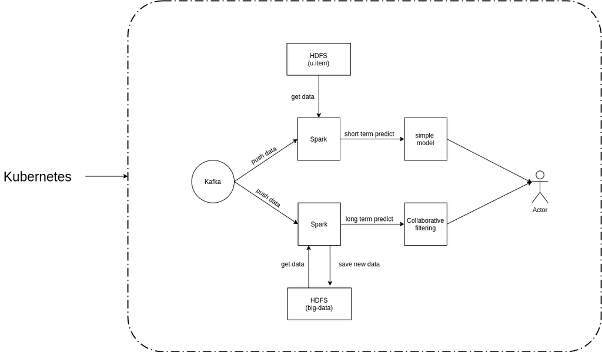

Hệ thống được thiết kế theo mô hình lambda, chia ra thành các phần chính :

1. Kafka : truyền dữ liệu của người dùng bao dưới dạng json bao gồm các trường userId, movieId, rating
2. Spark : nhận dữ liệu từ kafka, tạo model ML và đưa kết quả cho người dùng
3. model ML  
   3.1. Simple model : giựa vào dữ liệu streaming đưa ra các bộ phim tương tự  
   3.2. Collaborative filtering : dựa vào dữ liệu rating nghiên cứu xu hướng người dùng
4. HDFS : lưu dữ liệu phân tán
5. Kubernetes : toàn bộ các thành phần trên được triển khai trên hệ thống kubernetes

## Khởi tạo

```python
%%time
import findspark
findspark.init()
import pyspark
import numpy as np
import pandas as pd
from pyspark.context import SparkContext
from pyspark.sql.session import SparkSession
from pyspark.sql.types import *
from pyspark.ml.recommendation import ALS, ALSModel
from pyspark.mllib.evaluation import RegressionMetrics, RankingMetrics
from pyspark.ml.evaluation import RegressionEvaluator
from sklearn.metrics.pairwise import cosine_similarity
from pyspark.sql.functions import monotonically_increasing_id
import os
```

```
CPU times: user 903 ms, sys: 260 ms, total: 1.16 s
Wall time: 878 ms
```

[figure not shown]

```python
os.environ['PYSPARK_SUBMIT_ARGS'] = 'pyspark-shell'

# config for submit spark to kubernetes
conf = pyspark.SparkConf()
conf.setMaster("k8s://https://kubernetes.default.svc.cluster.local:443")
conf.setAppName("notebook")
conf.set("spark.kubernetes.container.image", "hacmao/spark-py:v3.0.0")
conf.set("spark.kubernetes.namespace", "project")
conf.set("spark.kubernetes.authenticate.driver.serviceAccountName", "spark")
conf.set("spark.executor.instances", "4")
conf.set("spark.executor.memory", "512m")
conf.set("spark.executor.cores", "1")
conf.set("spark.driver.host", "pyspark-driver.project.svc.cluster.local")
conf.set("spark.jars.packages", "org.apache.spark:spark-sql-kafka-0-10_2.12:3.0.1")
conf.set("spark.sql.parquet.compression.codec", "gzip")

# hdfs url hdfs://<namenode-pod>.<namenode-svc>.<namespace>.svc.cluster.local:9000/<file-path>
HDFS_URI = "hdfs://hdfs-hadoop-hdfs-nn-0.hdfs-hadoop-hdfs-nn.project.svc.cluster.local:9000"
```

```python
%%time
# create spark session
sparkSession = SparkSession.builder \
    .config(conf=conf) \
    .getOrCreate()
sc = sparkSession.sparkContext
```

```
CPU times: user 50.1 ms, sys: 18.4 ms, total: 68.4 ms
Wall time: 36.7 s
```

## Monitoring

[figure not shown]

# Data preprocessing

```python
%%time
data = sparkSession.read.csv(HDFS_URI + "/ml-100k/u.data", sep='\t',inferSchema=True, enforceSchema=False, columnNameOfCorruptRecord='broken')
data.show()
data.printSchema()
```

```
+---+----+---+---------+
|_c0| _c1|_c2|      _c3|
+---+----+---+---------+
|196| 242|  3|881250949|
|186| 302|  3|891717742|
| 22| 377|  1|878887116|
|244|  51|  2|880606923|
|166| 346|  1|886397596|
|298| 474|  4|884182806|
|115| 265|  2|881171488|
|253| 465|  5|891628467|
|305| 451|  3|886324817|
|  6|  86|  3|883603013|
| 62| 257|  2|879372434|
|286|1014|  5|879781125|
|200| 222|  5|876042340|
|210|  40|  3|891035994|
|224|  29|  3|888104457|
|303| 785|  3|879485318|
|122| 387|  5|879270459|
|194| 274|  2|879539794|
|291|1042|  4|874834944|
|234|1184|  2|892079237|
+---+----+---+---------+
only showing top 20 rows

root
 |-- _c0: integer (nullable = true)
 |-- _c1: integer (nullable = true)
 |-- _c2: integer (nullable = true)
 |-- _c3: integer (nullable = true)

CPU times: user 4.82 ms, sys: 1.15 ms, total: 5.97 ms
Wall time: 11.1 s
```

```python
newNames = ["userId", "movieId", "rating", "timestamp"]
dfRenamed = data.toDF(*newNames)
dfRenamed.printSchema()
```

```
root
 |-- userId: integer (nullable = true)
 |-- movieId: integer (nullable = true)
 |-- rating: integer (nullable = true)
 |-- timestamp: integer (nullable = true)
```

```python
ratings = (dfRenamed.select('userId', 'movieId', 'rating')).cache()
print(ratings)
ratings.printSchema()
```

```
DataFrame[userId: int, movieId: int, rating: int]
root
 |-- userId: integer (nullable = true)
 |-- movieId: integer (nullable = true)
 |-- rating: integer (nullable = true)
```

### Mô tả số lượng các lượt đánh giá của người dùng theo điểm đánh giá, có thể thấy phần lớn lượng đánh giá sẽ là đánh giá 3 điểm trở lên.

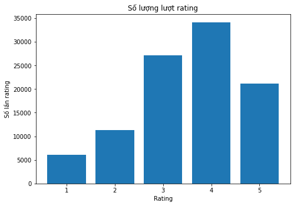

```
Total = 100000
```

```python
%matplotlib inline
import matplotlib.pyplot as plt
Dict = ratings.groupBy("rating").count().toPandas().sort_values(by="rating").to_dict()
fig = plt.figure()
ax = fig.add_axes([0,0,1,1])
ax.bar([str(Dict['rating'][i]) for i in Dict['rating']], [Dict['count'][i] for i in Dict['count']])
plt.title('Số lượng lượt rating')
plt.ylabel('Số lần rating')
plt.xlabel('Rating')
plt.show()
print("Total = " + str(data.count()))
```

### Mô tả số lượt đánh giá dựa theo phim, ta có thể thấy chủ yếu các phim được đánh giá ít, các phim có nhiều lượt đánh giá sẽ có số lượng thấp

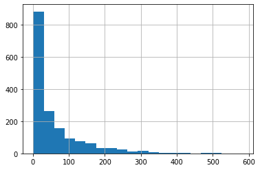

```python
%matplotlib inline
Dict2 = ratings.groupBy("movieId").count().toPandas().sort_values(by="count")["count"].hist(bins=20)
```

### Mô tả số lượt đánh giá dựa theo người dùng, ta có thể thấy số người ít đánh giá phim chiếm đa số, số lượng người đánh giá nhiều thấp

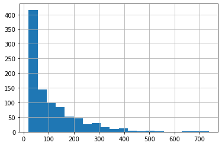

```python
%matplotlib inline
Dict4 = ratings.groupBy("userId").count().toPandas().sort_values(by="count")["count"].hist(bins=20)
```

### Mô tả điểm đánh giá trung bình của một bộ phim, có thể thấy phần lớn các bộ phim sẽ có điểm đánh giá trung bình trong khoảng 2.5 đến 4

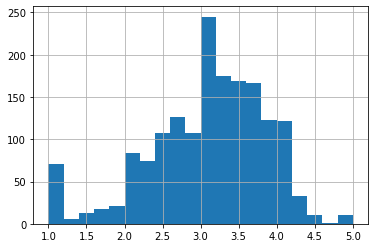

```python
%matplotlib inline
Dict3 = ratings.groupBy("movieId").avg("rating").toPandas().sort_values(by="avg(rating)")["avg(rating)"].hist(bins=20)
```

```python
(train, test) = ratings.randomSplit([0.8, 0.2])
display(train)
```

```
DataFrame[userId: int, movieId: int, rating: int]
```

## Tìm top 10 movie tương đồng để đưa ra gợi ý ngắn hạn

```python
data_schema = StructType([
    StructField('movie id', IntegerType(), True),
    StructField('movie title', StringType(), True),
    StructField('release date', StringType(), True),
    StructField('video release date', StringType(), True),
    StructField('IMDb URL', StringType(), True),
    StructField('unknown',IntegerType(), True),
    StructField('Action',IntegerType(), True),
    StructField('Adventure',IntegerType(), True),
    StructField('Animation',IntegerType(), True),
    StructField('Children\'s',IntegerType(), True),
    StructField('Comedy',IntegerType(), True),
    StructField('Crime',IntegerType(), True),
    StructField('Documentary',IntegerType(), True),
    StructField('Drama',IntegerType(), True),
    StructField('Fantasy',IntegerType(), True),
    StructField('Film-Noir',IntegerType(), True),
    StructField('Horror',IntegerType(), True),
    StructField('Musical',IntegerType(), True),
    StructField('Mystery',IntegerType(), True),
    StructField('Romance',IntegerType(), True),
    StructField('Sci-Fi',IntegerType(), True),
    StructField('Thriller',IntegerType(), True),
    StructField('War',IntegerType(), True),
    StructField('Western',IntegerType(), True)
])

ml100k = sparkSession.read.csv(HDFS_URI + "/ml-100k/u.item", sep='|', header=True, schema= data_schema).cache()
ml100k.printSchema()
```

```
root
 |-- movie id: integer (nullable = true)
 |-- movie title: string (nullable = true)
 |-- release date: string (nullable = true)
 |-- video release date: string (nullable = true)
 |-- IMDb URL: string (nullable = true)
 |-- unknown: integer (nullable = true)
 |-- Action: integer (nullable = true)
 |-- Adventure: integer (nullable = true)
 |-- Animation: integer (nullable = true)
 |-- Children's: integer (nullable = true)
 |-- Comedy: integer (nullable = true)
 |-- Crime: integer (nullable = true)
 |-- Documentary: integer (nullable = true)
 |-- Drama: integer (nullable = true)
 |-- Fantasy: integer (nullable = true)
 |-- Film-Noir: integer (nullable = true)
 |-- Horror: integer (nullable = true)
 |-- Musical: integer (nullable = true)
 |-- Mystery: integer (nullable = true)
 |-- Romance: integer (nullable = true)
 |-- Sci-Fi: integer (nullable = true)
 |-- Thriller: integer (nullable = true)
 |-- War: integer (nullable = true)
 |-- Western: integer (nullable = true)
```

```python
data = ml100k.select('Action', 'Adventure','Animation', 'Children\'s',
                      'Comedy', 'Crime', 'Documentary', 'Drama', 'Fantasy',
                     'Film-Noir', 'Horror', 'Musical', 'Mystery', 'Romance',
                      'Sci-Fi', 'Thriller', 'War', 'Western').cache()
data.show()
print(type(data))
```

```
+------+---------+---------+----------+------+-----+-----------+-----+-------+---------+------+-------+-------+-------+------+--------+---+-------+
|Action|Adventure|Animation|Children's|Comedy|Crime|Documentary|Drama|Fantasy|Film-Noir|Horror|Musical|Mystery|Romance|Sci-Fi|Thriller|War|Western|
+------+---------+---------+----------+------+-----+-----------+-----+-------+---------+------+-------+-------+-------+------+--------+---+-------+
|     1|        1|        0|         0|     0|    0|          0|    0|      0|        0|     0|      0|      0|      0|     0|       1|  0|      0|
|     0|        0|        0|         0|     0|    0|          0|    0|      0|        0|     0|      0|      0|      0|     0|       1|  0|      0|
|     1|        0|        0|         0|     1|    0|          0|    1|      0|        0|     0|      0|      0|      0|     0|       0|  0|      0|
|     0|        0|        0|         0|     0|    1|          0|    1|      0|        0|     0|      0|      0|      0|     0|       1|  0|      0|
|     0|        0|        0|         0|     0|    0|          0|    1|      0|        0|     0|      0|      0|      0|     0|       0|  0|      0|
|     0|        0|        0|         0|     0|    0|          0|    1|      0|        0|     0|      0|      0|      0|     1|       0|  0|      0|
|     0|        0|        0|         1|     1|    0|          0|    1|      0|        0|     0|      0|      0|      0|     0|       0|  0|      0|
|     0|        0|        0|         0|     0|    0|          0|    1|      0|        0|     0|      0|      0|      0|     0|       0|  0|      0|
|     0|        0|        0|         0|     0|    0|          0|    1|      0|        0|     0|      0|      0|      0|     0|       0|  1|      0|
|     0|        0|        0|         0|     0|    1|          0|    0|      0|        0|     0|      0|      0|      0|     0|       1|  0|      0|
|     0|        0|        0|         0|     0|    1|          0|    0|      0|        0|     0|      0|      0|      0|     0|       1|  0|      0|
|     0|        0|        0|         0|     1|    0|          0|    0|      0|        0|     0|      0|      0|      0|     0|       0|  0|      0|
|     0|        0|        0|         0|     0|    0|          0|    1|      0|        0|     0|      0|      0|      1|     0|       0|  0|      0|
|     0|        0|        0|         0|     0|    0|          0|    1|      0|        0|     0|      0|      0|      0|     0|       0|  0|      0|
|     0|        0|        0|         0|     1|    0|          0|    0|      0|        0|     0|      0|      0|      1|     0|       0|  0|      0|
|     1|        0|        0|         0|     1|    1|          0|    0|      0|        0|     1|      0|      0|      0|     0|       1|  0|      0|
|     0|        0|        0|         0|     0|    0|          0|    1|      0|        0|     0|      0|      0|      0|     0|       0|  0|      0|
|     0|        0|        0|         0|     0|    0|          0|    1|      0|        0|     0|      0|      0|      0|     0|       0|  0|      0|
|     0|        0|        0|         0|     0|    0|          0|    1|      0|        0|     0|      0|      0|      1|     0|       0|  0|      0|
|     1|        1|        0|         0|     1|    0|          0|    0|      0|        0|     0|      1|      0|      0|     0|       1|  0|      0|
+------+---------+---------+----------+------+-----+-----------+-----+-------+---------+------+-------+-------+-------+------+--------+---+-------+
only showing top 20 rows

<class 'pyspark.sql.dataframe.DataFrame'>
```

```python
print(data.columns)
```

```
['Action', 'Adventure', 'Animation', "Children's", 'Comedy', 'Crime', 'Documentary', 'Drama', 'Fantasy', 'Film-Noir', 'Horror', 'Musical', 'Mystery', 'Romance', 'Sci-Fi', 'Thriller', 'War', 'Western']
```

```python
# shape
n_items = data.count()
n_columns = len(data.columns)
print("Số items của data: {}".format(n_items))
print("Số columns của data: {}".format(n_columns))
```

```
Số items của data: 1681
Số columns của data: 18
```

```python
itemInfo = ml100k.collect()
itemInfo = np.array(itemInfo)
itemFeatures = itemInfo[:, -19:]
print(itemFeatures.shape)
```

```
(1681, 19)
```

```python
# mostSimilarMovie = []
cosineSimilarity = np.zeros([n_items, n_items])
# print(cosineSimilarity)
cosineSimilarity = cosine_similarity(itemFeatures, itemFeatures)
print(cosineSimilarity.shape)

index = np.argsort(cosineSimilarity, axis = 1)
# print(index)
cosineSimilarity = np.take_along_axis(cosineSimilarity, index, axis = 1)
print(cosineSimilarity)

mostSimilarMovie = cosineSimilarity[:, -10:]
# print(mostSimilarMovie.shape)
mostSimilarMovieIndex = index[:, -11:]
print(mostSimilarMovieIndex)
```

```
(1681, 1681)
[[0.        0.        0.        ... 1.        1.        1.       ]
 [0.        0.        0.        ... 1.        1.        1.       ]
 [0.        0.        0.        ... 0.8660254 1.        1.       ]
 ...
 [0.        0.        0.        ... 1.        1.        1.       ]
 [0.        0.        0.        ... 1.        1.        1.       ]
 [0.        0.        0.        ... 1.        1.        1.       ]]
[[ 928  116 1103 ...  564  115    0]
 [1088 1251 1246 ...  216  981  973]
 [ 710 1401  693 ... 1136    2   72]
 ...
 [1288 1313  244 ...  714  304 1171]
 [1005 1175 1176 ... 1525 1498 1204]
 [1387 1386  385 ...  733 1389 1680]]
```

```python
def recommendMovie(movieId) :
    listMovie = mostSimilarMovieIndex[movieId-1]
    # print(listMovie)
    for i in reversed(listMovie):
        if (movieId != i):
            print(itemInfo[i, 1])
```

## Collaborative Filter

### Parameters of ALS Model in PySpark realization are following:

1. NumBlocks is the number of blocks the users and items will be partitioned into in order to parallelize computation.
2. rank is the number of latent factors in the model.
3. maxIter is the maximum number of iterations to run.
4. regParam specifies the regularization parameter in ALS.
5. implicitPrefs specifies whether to use the explicit feedback ALS variant or one adapted for implicit feedback data (defaults to false which means using explicit feedback).
6. alpha is a parameter applicable to the implicit feedback variant of ALS that governs the baseline confidence in preference observations (defaults to 1.0).

```python
%%time
als = ALS(
            rank = 10,
            maxIter = 15,
            regParam = 0.01,
            userCol = "userId",
            itemCol = "movieId",
            ratingCol = "rating",
            coldStartStrategy = "drop",
            implicitPrefs = False
        )

model = als.fit(train)
```

```
CPU times: user 10.4 ms, sys: 9.99 ms, total: 20.4 ms
Wall time: 13.6 s
```

```python
%%time
# Evaluate model by computing RMSE on train data
predictions = model.transform(test)
evaluator = RegressionEvaluator(metricName = 'rmse', labelCol = "rating", predictionCol = "prediction")
RMSE = evaluator.evaluate(predictions)
```

```
CPU times: user 5.77 ms, sys: 7.7 ms, total: 13.5 ms
Wall time: 16.3 s
```

```python
%%time
predictions.show(20)
```

```
+------+-------+------+----------+
|userId|movieId|rating|prediction|
+------+-------+------+----------+
|   580|    148|     4| 2.9841213|
|    27|    148|     3| 1.9885523|
|   271|    148|     3| 2.7774465|
|   222|    148|     2| 3.8333523|
|   372|    148|     5| 3.6213803|
|   727|    148|     2|  3.451693|
|   618|    148|     3|  2.692703|
|   896|    148|     2|  2.675546|
|   308|    148|     3| 3.1558392|
|   328|    148|     3|  2.910706|
|   479|    148|     2| 3.1340764|
|    54|    148|     3| 4.0652432|
|    92|    148|     2|   2.77127|
|   347|    148|     3| 3.0430467|
|   455|    148|     3| 3.0884206|
|    15|    148|     3|  2.512221|
|   733|    148|     3| 1.1241531|
|   706|    148|     4| 4.5310826|
|   533|    148|     3| 3.6163082|
|   403|    148|     5|  4.748837|
+------+-------+------+----------+
only showing top 20 rows

CPU times: user 2.88 ms, sys: 0 ns, total: 2.88 ms
Wall time: 8.95 s
```

```python
print("Root-mean-square error = " + str(RMSE))
```

```
Root-mean-square error = 1.1048392582427458
```

```python
%%time
# Generate top 10 movie recommendations for each user
userRecs = model.recommendForAllUsers(10)
userRecs.show()
# Generate top 10 user recommendations for each movie
movieRecs = model.recommendForAllItems(10)
movieRecs.show()
```

```
+------+--------------------+
|userId|     recommendations|
+------+--------------------+
|   471|[[1184, 18.149343...|
|   463|[[432, 6.437394],...|
|   833|[[390, 8.363742],...|
|   496|[[700, 7.7585096]...|
|   148|[[624, 11.056952]...|
|   540|[[1643, 5.6477914...|
|   392|[[1643, 6.6869], ...|
|   243|[[621, 5.572508],...|
|   623|[[592, 7.826023],...|
|   737|[[320, 13.683144]...|
|   897|[[1615, 7.179225]...|
|   858|[[1005, 7.724079]...|
|    31|[[390, 7.03425], ...|
|   516|[[464, 8.4396105]...|
|   580|[[1176, 9.021987]...|
|   251|[[580, 7.009867],...|
|   451|[[1483, 8.096369]...|
|    85|[[1643, 5.9938426...|
|   137|[[426, 10.583757]...|
|   808|[[718, 10.147153]...|
+------+--------------------+
only showing top 20 rows

+-------+--------------------+
|movieId|     recommendations|
+-------+--------------------+
|   1580|[[405, 1.0192448]...|
|    471|[[565, 5.587706],...|
|   1591|[[914, 9.524269],...|
|   1342|[[50, 4.2803], [8...|
|    463|[[219, 8.511306],...|
|    833|[[471, 9.94406], ...|
|   1645|[[651, 6.7251773]...|
|    496|[[520, 7.884863],...|
|    148|[[565, 5.823077],...|
|   1088|[[471, 9.506329],...|
|   1238|[[364, 5.1078715]...|
|    540|[[212, 6.374194],...|
|   1460|[[520, 4.7289424]...|
|    392|[[38, 7.330994], ...|
|   1522|[[475, 4.983396],...|
|    243|[[471, 8.75958], ...|
|    623|[[212, 9.333024],...|
|   1483|[[726, 10.766276]...|
|   1084|[[471, 11.031806]...|
|   1025|[[34, 8.1838255],...|
+-------+--------------------+
only showing top 20 rows

CPU times: user 5.33 ms, sys: 993 µs, total: 6.32 ms
Wall time: 19 s
```

## Kafka

Một số hàm cơ bản để xử lý với luồng stream :

1. `json_load` : phân tích dữ liệu tới dưới dạng json và chuyển về list
2. `getAmount` : trả về số thông tin hiện có trong memory
3. `getNewRecords` : trả về những record mới toiws

```python
from pyspark.sql.functions import col, column
from ast import literal_eval

def json_load(s) :
    try :
        return literal_eval(s.asDict()['value'])
    except Exception as e :
        print(e)
        return None

def json_load2(s) :
    try :
        return literal_eval(s)
    except Exception as e :
        print(e)
        return None

def getAmount() :
    return sparkSession.sql("select count(*) from ds")\
            .rdd.map(lambda a : a['count(1)']).collect()[0]

def getNewRecords() :
    global oldCount
    data = sparkSession.sql("SELECT * from ds")
    res = data.rdd.zipWithIndex().filter(lambda c : c[1] >= oldCount) \
            .map(lambda col: json_load(col[0])) \
            .filter(lambda col : col != None) \
            .collect()
    oldCount = getAmount()
    return res
```

Trong trường hợp này, ta mô phỏng dữ liệu người dùng được truyền từ kafka tới với topic là `messages`. Thực hiện dùng pyspark để lắng nghe luồng stream này. Với mỗi 5s, chúng ta sẽ tiến hành ghi ra memory với view là `ds`.

```python
# create new stream subcribe topic "messsages" to receive lastest messages
df = sparkSession.readStream.format("kafka") \
    .option("kafka.bootstrap.servers", "kafka:9092")\
    .option("subscribe", "messages")\
    .option("startingOffsets", """{"messages" : {"0" : -1}}""") \
    .load()

# write to memory each 5s
ds = df.selectExpr("CAST(value AS STRING)")
ds.writeStream \
    .queryName("ds").format('memory') \
    .trigger(processingTime='5 seconds') \
    .start()
```

```
<pyspark.sql.streaming.StreamingQuery at 0x7fc22392a490>
```

Đưa ra gợi ý cho người dùng bằng các dự đoán ngắn hạn, top 10 movie dựa trên movie người dùng vừa thực hiện vote. Với những vote kém, sẽ không đưa ra recommend phim tương tự.

```python
import time

oldCount = getAmount()
time.sleep(20)   # wait 20s
new_record = getNewRecords()
print("[***] Number of new record : %d" % len(new_record))
for record in new_record :
    print("\n--------------------------------------------------------")
    print("\t[*] Recommend movie for user %d\n" % record['userId'])
    if record['rating'] > 3 :
        recommendMovie(record['movieId'])
    else :
        print("\tHappy watching")
```

```
[***] Number of new record : 14

--------------------------------------------------------
	[*] Recommend movie for user 9270

	Happy watching

--------------------------------------------------------
	[*] Recommend movie for user 200

	Happy watching

--------------------------------------------------------
	[*] Recommend movie for user 8607

	Happy watching

--------------------------------------------------------
	[*] Recommend movie for user 8489

	Happy watching

--------------------------------------------------------
	[*] Recommend movie for user 5722

	Happy watching

--------------------------------------------------------
	[*] Recommend movie for user 204

Star Trek V: The Final Frontier (1989)
Stargate (1994)
Star Trek: Generations (1994)
Judge Dredd (1995)
Star Trek: First Contact (1996)
Star Trek VI: The Undiscovered Country (1991)
Star Trek: The Motion Picture (1979)
Star Trek: The Wrath of Khan (1982)
Time Tracers (1995)
Star Trek IV: The Voyage Home (1986)
```

[output cut: 76 more lines]

```
Squeeze (1996)
Man Without a Face, The (1993)
Age of Innocence, The (1993)
Gabbeh (1996)
Mondo (1996)

--------------------------------------------------------
	[*] Recommend movie for user 8471

	Happy watching

--------------------------------------------------------
	[*] Recommend movie for user 5205

	Happy watching
```

### Update data and save to HDFS

Tạo mới dataframe từ dữ liệu trong luồng stream

```python
from pyspark.sql import Row

data_schema = StructType([
    StructField('userId',IntegerType(), True),
    StructField('movieId',IntegerType(), True),
    StructField('rating',IntegerType(), True)
])

data = sparkSession.sql("select * from ds").rdd.map(lambda col: json_load2(col[0])).collect()
new_data = sparkSession.createDataFrame(data, data_schema)
new_data.printSchema()
```

```
root
 |-- userId: integer (nullable = true)
 |-- movieId: integer (nullable = true)
 |-- rating: integer (nullable = true)
```

```python
update_ratings = ratings.union(new_data)
update_ratings.count()
```

```
100014
```

```python
update_ratings.write.format("csv").mode('overwrite').save(HDFS_URI + "/ml-100k-update")

# check for new data
new_data = sparkSession.read.csv(HDFS_URI + "/ml-100k-update")
new_data.show()
```

```
+---+----+---+
|_c0| _c1|_c2|
+---+----+---+
|196| 242|  3|
|186| 302|  3|
| 22| 377|  1|
|244|  51|  2|
|166| 346|  1|
|298| 474|  4|
|115| 265|  2|
|253| 465|  5|
|305| 451|  3|
|  6|  86|  3|
| 62| 257|  2|
|286|1014|  5|
|200| 222|  5|
|210|  40|  3|
|224|  29|  3|
|303| 785|  3|
|122| 387|  5|
|194| 274|  2|
|291|1042|  4|
|234|1184|  2|
+---+----+---+
only showing top 20 rows
```

```python
# sc.stop()
```